# Bellabeat Analytics

Joanne Fil

8/15/2021

## Case Study 2: Bellabeat Analysis

We are going to analyze smart device usage data in order to gain insight into how people are already using their smart devices.

### Install packages and set directory

```r
library(tidyverse)  #helps wrangle data
library(lubridate)  #helps wrangle date attributes
```

```r
library(ggplot2)  #helps visualize data
library(dplyr)
```

## Step 1: Collect data

Upload data - some files are presented in narrow (long) and wide format but present the same information, I prefer the long format so will exclude the wide ones.

The ‘daily activity’ file includes the same information as the ‘daily intensity’, ‘daily calories’ and ‘daily steps’, so we don’t need to load those files separately.

```r
daily_activity <- read.csv("Daily/dailyActivity_merged.csv")
#daily_calories <- read.csv("Daily/dailyCalories_merged.csv")
#daily_intensities <- read.csv("Daily/dailyIntensities_merged.csv")
#daily_steps <- read.csv("Daily/dailySteps_merged.csv")
day_sleep <- read.csv("Daily/sleepDay_merged.csv")
weightLogInfo <- read.csv("Daily/weightLogInfo_merged.csv")
```

Let’s explore some of the tables.

```r
head(daily_activity)
```

```
##           Id ActivityDate TotalSteps TotalDistance TrackerDistance
## 1 1503960366    4/12/2016      13162          8.50            8.50
## 2 1503960366    4/13/2016      10735          6.97            6.97
## 3 1503960366    4/14/2016      10460          6.74            6.74
## 4 1503960366    4/15/2016       9762          6.28            6.28
## 5 1503960366    4/16/2016      12669          8.16            8.16
## 6 1503960366    4/17/2016       9705          6.48            6.48
##   LoggedActivitiesDistance VeryActiveDistance ModeratelyActiveDistance
## 1                        0               1.88                     0.55
## 2                        0               1.57                     0.69
## 3                        0               2.44                     0.40
## 4                        0               2.14                     1.26
## 5                        0               2.71                     0.41
## 6                        0               3.19                     0.78
##   LightActiveDistance SedentaryActiveDistance VeryActiveMinutes
## 1                6.06                       0                25
## 2                4.71                       0                21
## 3                3.91                       0                30
## 4                2.83                       0                29
## 5                5.04                       0                36
## 6                2.51                       0                38
##   FairlyActiveMinutes LightlyActiveMinutes SedentaryMinutes Calories
## 1                  13                  328              728     1985
## 2                  19                  217              776     1797
## 3                  11                  181             1218     1776
## 4                  34                  209              726     1745
## 5                  10                  221              773     1863
## 6                  20                  164              539     1728
```

```r
colnames(daily_activity)
```

```
##  [1] "Id"                       "ActivityDate"
##  [3] "TotalSteps"               "TotalDistance"
##  [5] "TrackerDistance"          "LoggedActivitiesDistance"
##  [7] "VeryActiveDistance"       "ModeratelyActiveDistance"
##  [9] "LightActiveDistance"      "SedentaryActiveDistance"
## [11] "VeryActiveMinutes"        "FairlyActiveMinutes"
## [13] "LightlyActiveMinutes"     "SedentaryMinutes"
## [15] "Calories"
```

```r
head(day_sleep)
```

```
##           Id              SleepDay TotalSleepRecords TotalMinutesAsleep
## 1 1503960366 4/12/2016 12:00:00 AM                 1                327
## 2 1503960366 4/13/2016 12:00:00 AM                 2                384
## 3 1503960366 4/15/2016 12:00:00 AM                 1                412
## 4 1503960366 4/16/2016 12:00:00 AM                 2                340
## 5 1503960366 4/17/2016 12:00:00 AM                 1                700
## 6 1503960366 4/19/2016 12:00:00 AM                 1                304
##   TotalTimeInBed
## 1            346
## 2            407
## 3            442
## 4            367
## 5            712
## 6            320
```

```r
colnames(day_sleep)
```

```
## [1] "Id"                 "SleepDay"           "TotalSleepRecords"
## [4] "TotalMinutesAsleep" "TotalTimeInBed"
```

```r
head(weightLogInfo)
```

```
##           Id                  Date WeightKg WeightPounds Fat   BMI
## 1 1503960366  5/2/2016 11:59:59 PM     52.6     115.9631  22 22.65
## 2 1503960366  5/3/2016 11:59:59 PM     52.6     115.9631  NA 22.65
## 3 1927972279  4/13/2016 1:08:52 AM    133.5     294.3171  NA 47.54
## 4 2873212765 4/21/2016 11:59:59 PM     56.7     125.0021  NA 21.45
## 5 2873212765 5/12/2016 11:59:59 PM     57.3     126.3249  NA 21.69
## 6 4319703577 4/17/2016 11:59:59 PM     72.4     159.6147  25 27.45
##   IsManualReport        LogId
## 1           True 1.462234e+12
## 2           True 1.462320e+12
## 3          False 1.460510e+12
## 4           True 1.461283e+12
## 5           True 1.463098e+12
## 6           True 1.460938e+12
```

```r
colnames(weightLogInfo)
```

```
## [1] "Id"             "Date"           "WeightKg"       "WeightPounds"
## [5] "Fat"            "BMI"            "IsManualReport" "LogId"
```

*Note* description of variables explored and column names in each csv file has been summarized in the excel file called "Datasets_organization’ (provided within the same github file).

## Step 2: Make some observations

How many unique participants are in each dataframe?

```r
n_distinct(daily_activity$Id)
```

```
## [1] 33
```

```r
n_distinct(day_sleep$Id)
```

```
## [1] 24
```

```r
n_distinct(weightLogInfo$Id)
```

```
## [1] 8
```

How many observations in each dataframe?

```r
dim(daily_activity)
```

```
## [1] 940  15
```

```r
dim(day_sleep)
```

```
## [1] 413   5
```

```r
dim(weightLogInfo)
```

```
## [1] 67  8
```

Data types

```r
str(daily_activity)
```

```
## 'data.frame':    940 obs. of  15 variables:
##  $ Id                      : num  1.5e+09 1.5e+09 1.5e+09 1.5e+09 1.5e+09 ...
##  $ ActivityDate            : chr  "4/12/2016" "4/13/2016" "4/14/2016" "4/15/2016" ...
##  $ TotalSteps              : int  13162 10735 10460 9762 12669 9705 13019 15506 10544 9819 ...
##  $ TotalDistance           : num  8.5 6.97 6.74 6.28 8.16 ...
##  $ TrackerDistance         : num  8.5 6.97 6.74 6.28 8.16 ...
##  $ LoggedActivitiesDistance: num  0 0 0 0 0 0 0 0 0 0 ...
##  $ VeryActiveDistance      : num  1.88 1.57 2.44 2.14 2.71 ...
##  $ ModeratelyActiveDistance: num  0.55 0.69 0.4 1.26 0.41 ...
##  $ LightActiveDistance     : num  6.06 4.71 3.91 2.83 5.04 ...
##  $ SedentaryActiveDistance : num  0 0 0 0 0 0 0 0 0 0 ...
##  $ VeryActiveMinutes       : int  25 21 30 29 36 38 42 50 28 19 ...
##  $ FairlyActiveMinutes     : int  13 19 11 34 10 20 16 31 12 8 ...
##  $ LightlyActiveMinutes    : int  328 217 181 209 221 164 233 264 205 211 ...
##  $ SedentaryMinutes        : int  728 776 1218 726 773 539 1149 775 818 838 ...
##  $ Calories                : int  1985 1797 1776 1745 1863 1728 1921 2035 1786 1775 ...
```

```r
str(day_sleep)
```

```
## 'data.frame':    413 obs. of  5 variables:
##  $ Id                : num  1.5e+09 1.5e+09 1.5e+09 1.5e+09 1.5e+09 ...
##  $ SleepDay          : chr  "4/12/2016 12:00:00 AM" "4/13/2016 12:00:00 AM" "4/15/2016 12:00:00 AM" "4/16/2016 12:00:00 AM" ...
##  $ TotalSleepRecords : int  1 2 1 2 1 1 1 1 1 1 ...
##  $ TotalMinutesAsleep: int  327 384 412 340 700 304 360 325 361 430 ...
##  $ TotalTimeInBed    : int  346 407 442 367 712 320 377 364 384 449 ...
```

```r
str(weightLogInfo)
```

```
## 'data.frame':    67 obs. of  8 variables:
##  $ Id            : num  1.50e+09 1.50e+09 1.93e+09 2.87e+09 2.87e+09 ...
##  $ Date          : chr  "5/2/2016 11:59:59 PM" "5/3/2016 11:59:59 PM" "4/13/2016 1:08:52 AM" "4/21/2016 11:59:59 PM" ...
##  $ WeightKg      : num  52.6 52.6 133.5 56.7 57.3 ...
##  $ WeightPounds  : num  116 116 294 125 126 ...
##  $ Fat           : int  22 NA NA NA NA 25 NA NA NA NA ...
##  $ BMI           : num  22.6 22.6 47.5 21.5 21.7 ...
##  $ IsManualReport: chr  "True" "True" "False" "True" ...
##  $ LogId         : num  1.46e+12 1.46e+12 1.46e+12 1.46e+12 1.46e+12 ...
```

## Step 3: Wrangle data and combine into a single file

We can combine the daily sleep and weight information to the daily activity, since they include the ID, to make one large data set.

First let’s split up the date and time columns and then remove duplicated rows.

```r
day_sleep_v2 <- separate(day_sleep, SleepDay, into = c("date", "time", "AM_PM"), sep = " ") %>% distinct()
weightLogInfo_v2 <- separate(weightLogInfo, Date, into = c("date", "time","AM_PM"), sep = " ") %>% distinct()
```

Now remove duplicate rows and rename ‘ActivityDate’ to just ‘date’.

```r
daily_activity_v2 <- daily_activity %>% distinct()
daily_activity_v2 <-rename(daily_activity_v2,date = ActivityDate)
```

Combine datasets by ID and date, using outer join so ‘all = TRUE’.

```r
combined <- merge(daily_activity_v2, day_sleep_v2, by = c("Id", "date"), all = TRUE)
combined <- merge(combined, weightLogInfo_v2, by = c("Id", "date"), all = TRUE)
```

Rename time and AM_PM so we know which corresponds to which dataset.

```r
combined <- rename(combined,timeSleep = time.x, AM_PM_Sleep = AM_PM.x, timeweight = time.y,
                   AM_PM_Weight = AM_PM.y)
```

Some quick summary statistics of steps, distance, and sedentary minutes.

```r
combined %>%
  select(TotalSteps,
         TotalDistance,
         SedentaryMinutes) %>%
  summary()
```

```
##    TotalSteps    TotalDistance    SedentaryMinutes
##  Min.   :    0   Min.   : 0.000   Min.   :   0.0
##  1st Qu.: 3790   1st Qu.: 2.620   1st Qu.: 729.8
##  Median : 7406   Median : 5.245   Median :1057.5
##  Mean   : 7638   Mean   : 5.490   Mean   : 991.2
##  3rd Qu.:10727   3rd Qu.: 7.713   3rd Qu.:1229.5
##  Max.   :36019   Max.   :28.030   Max.   :1440.0
```

Remove data that has 0 steps and 0 distance, as this may influence summary statistics.

```r
combined_noZeros <- combined[!(combined$TotalSteps < 0.01),]
combined_noZeros %>%
  select(TotalSteps,
         TotalDistance,
         SedentaryMinutes) %>%
  summary()
```

```
##    TotalSteps    TotalDistance   SedentaryMinutes
##  Min.   :    4   Min.   : 0.00   Min.   :   0.0
##  1st Qu.: 4923   1st Qu.: 3.37   1st Qu.: 721.5
##  Median : 8053   Median : 5.59   Median :1021.0
##  Mean   : 8319   Mean   : 5.98   Mean   : 955.8
##  3rd Qu.:11092   3rd Qu.: 7.90   3rd Qu.:1189.0
##  Max.   :36019   Max.   :28.03   Max.   :1440.0
```

This group is getting an average of 8319 steps per day, 5.98 miles per day, and 955.8 minutes (around 16 hours) of being sedentary per day.

We’re getting a value of 0 for minimum distance which is strange because we removed 0 steps, so let’s check why we’re getting this value.

```r
combined_noZeros[which.min(combined_noZeros$TotalDistance),]
```

```
##             Id      date TotalSteps TotalDistance TrackerDistance
## 108 1844505072 4/27/2016          4             0               0
##     LoggedActivitiesDistance VeryActiveDistance ModeratelyActiveDistance
## 108                        0                  0                        0
##     LightActiveDistance SedentaryActiveDistance VeryActiveMinutes
## 108                   0                       0                 0
##     FairlyActiveMinutes LightlyActiveMinutes SedentaryMinutes Calories
## 108                   0                    1             1439     1348
##     timeSleep AM_PM_Sleep TotalSleepRecords TotalMinutesAsleep TotalTimeInBed
## 108      <NA>        <NA>                NA                 NA             NA
##     timeweight AM_PM_Weight WeightKg WeightPounds Fat BMI IsManualReport LogId
## 108       <NA>         <NA>       NA           NA  NA  NA           <NA>    NA
```

Participant only had 4 steps that day so that’s why there was no distance noted.

Now let’s do some quick summary statistics of total sleep records, total minutes asleep, and total time in bed.

```r
combined_noZeros %>%
  select(TotalSleepRecords,
         TotalMinutesAsleep,
         TotalTimeInBed) %>%
  summary()
```

```
##  TotalSleepRecords TotalMinutesAsleep TotalTimeInBed
##  Min.   :1.000     Min.   : 58.0      Min.   : 61.0
##  1st Qu.:1.000     1st Qu.:361.0      1st Qu.:403.8
##  Median :1.000     Median :432.5      Median :463.0
##  Mean   :1.119     Mean   :419.2      Mean   :458.5
##  3rd Qu.:1.000     3rd Qu.:490.0      3rd Qu.:526.0
##  Max.   :3.000     Max.   :796.0      Max.   :961.0
##  NA's   :453       NA's   :453        NA's   :453
```

On average participants slept around 419.2 minutes (around 7 hours) per day and spent 458.5 minutes (around 7.6 hours) per day in bed.

Now let’s do some quick summary statistics of calories and weight.

```r
combined_noZeros %>%
  select(Calories,
         WeightKg) %>%
  summary()
```

```
##     Calories       WeightKg
##  Min.   :  52   Min.   : 52.60
##  1st Qu.:1856   1st Qu.: 61.40
##  Median :2220   Median : 62.50
##  Mean   :2361   Mean   : 72.04
##  3rd Qu.:2832   3rd Qu.: 85.05
##  Max.   :4900   Max.   :133.50
##                 NA's   :796
```

This group burned an average of 2361 calories per day and weigh an average of 72.04 kg (158 lbs).

## Step 4: Plot

Let’s look at the relationship/pattern between steps taken in a day and sedentary minutes.

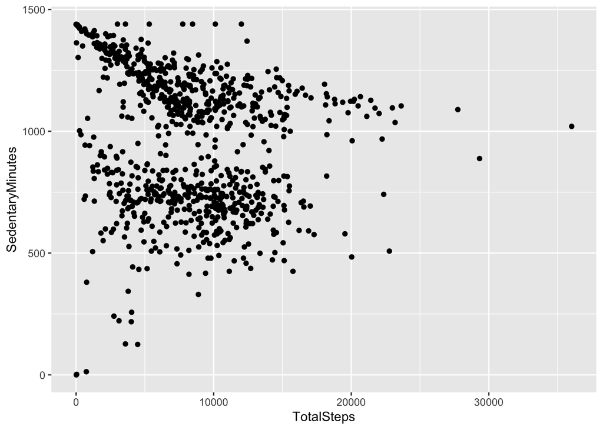

```r
ggplot(data=combined_noZeros, aes(x=TotalSteps, y=SedentaryMinutes)) + geom_point()
```

There appears to be somewhat of a negative relationship, but it is not very strong. We can attempt to perform a correlation analysis to see if there is a relationship or not.

To perform a correlation analysis, we must first check if x and y are normally distributed. Let’s perform the Shapiro-Wilk normality test to check. If p-value > 0.05, this means the distribution of the data is not significantly different from normal (meaning the data is normal).

```r
shapiro.test(combined_noZeros$TotalSteps)
```

```
##
##  Shapiro-Wilk normality test
##
## data:  combined_noZeros$TotalSteps
## W = 0.96393, p-value = 9.144e-14
```

The p-value is less than 0.05, meaning the data is not normal.

We can plot the data to visually see the distribution.

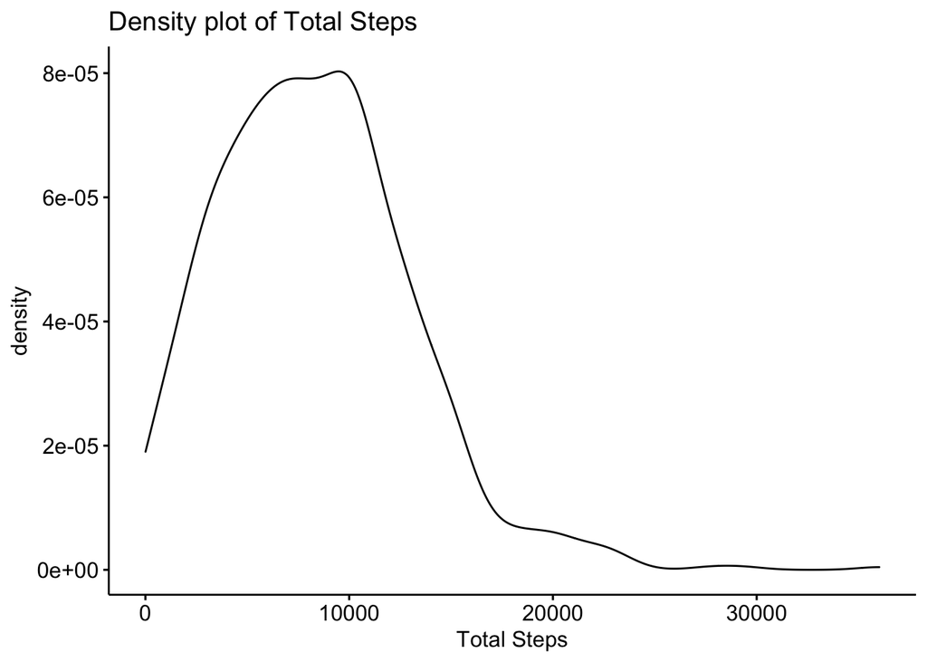

```r
library("ggpubr")
ggdensity(combined_noZeros$TotalSteps,
          main = "Density plot of Total Steps",
          xlab = "Total Steps")
```

Now let’s check the normality for y.

```r
shapiro.test(combined_noZeros$SedentaryMinutes)
```

```
##
##  Shapiro-Wilk normality test
##
## data:  combined_noZeros$SedentaryMinutes
## W = 0.95594, p-value = 2.031e-15
```

The data is less than 0.05 meaning the data is not normal.

We can plot the data to visually see the distribution.

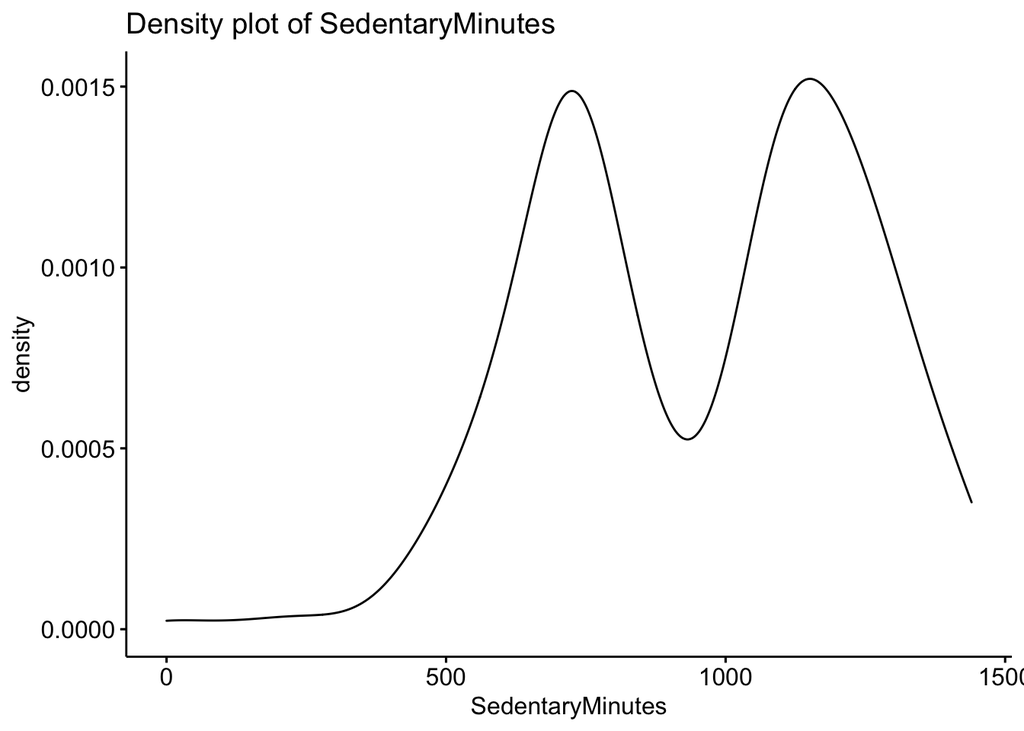

```r
ggdensity(combined_noZeros$SedentaryMinutes,
          main = "Density plot of SedentaryMinutes",
          xlab = "SedentaryMinutes")
```

Due to the data being not normal in neither x nor y, we cannot perform a correlation analysis without having to transform the data to normality (which we will not be doing in this practice).

Let’s move on and look at the relationship/pattern between minutes asleep and time in bed.

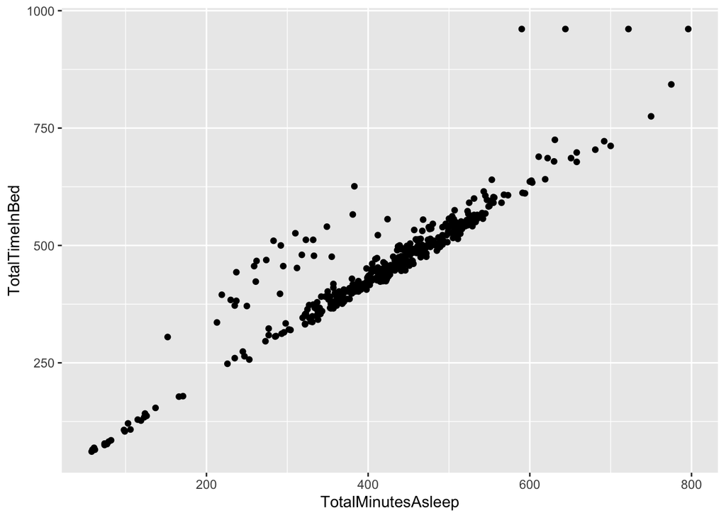

```r
ggplot(data=combined_noZeros, aes(x=TotalMinutesAsleep, y=TotalTimeInBed)) + geom_point()
```

There appears to be a strong postive relationship, but we cannot know for sure without performing a correlation analysis.

First let’s check the normality of x and y.

```r
shapiro.test(combined_noZeros$TotalMinutesAsleep)
```

```
##
##  Shapiro-Wilk normality test
##
## data:  combined_noZeros$TotalMinutesAsleep
## W = 0.95162, p-value = 2.48e-10
```

```r
shapiro.test(combined_noZeros$TotalTimeInBed)
```

```
##
##  Shapiro-Wilk normality test
##
## data:  combined_noZeros$TotalTimeInBed
## W = 0.91406, p-value = 1.608e-14
```

Let’s visualize the data sets to see their distributions.

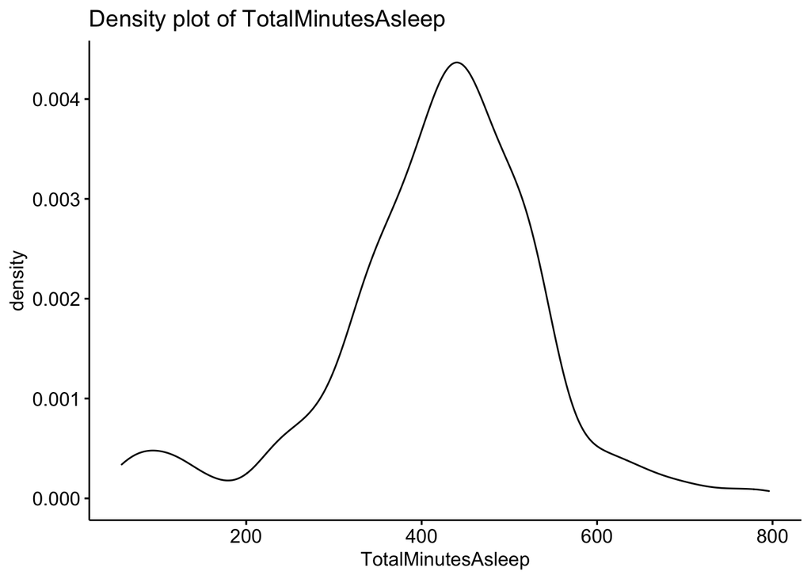

```r
ggdensity(combined_noZeros$TotalMinutesAsleep,
          main = "Density plot of TotalMinutesAsleep",
          xlab = "TotalMinutesAsleep")
```

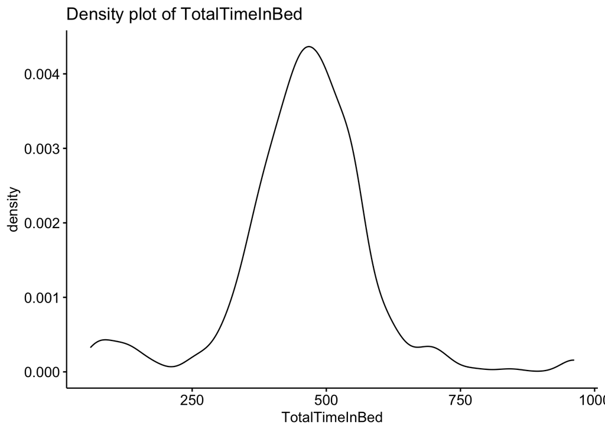

```r
ggdensity(combined_noZeros$TotalTimeInBed,
          main = "Density plot of TotalTimeInBed",
          xlab = "TotalTimeInBed")
```

Although the data does look normally distributed, it is not according to the Shapiro-Wilks test (their p-values were less than 0.05). Therefore, we cannot fully conclude that there is a positive relationship between the two.

Although they are not normal, let’s continue playing with the dataset for practice. There were some outliers (were above the straight line in the plot of minutes asleep and time in bed), are they possibly related in some way? Let’s see when we color the total steps.

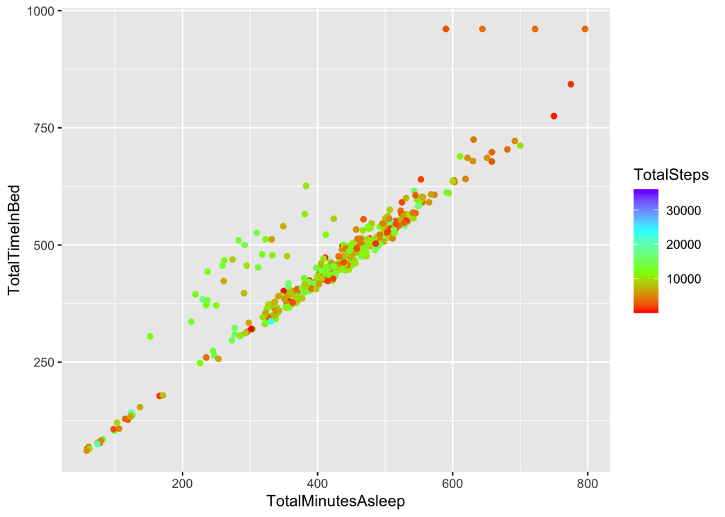

```r
ggplot(data=combined_noZeros, aes(x=TotalMinutesAsleep, y=TotalTimeInBed)) +
  geom_point(mapping = aes(color = TotalSteps)) +
  scale_colour_gradientn(colors=rainbow(4))
```

Let’s see if participants who sleep more take more steps or fewer steps per day.

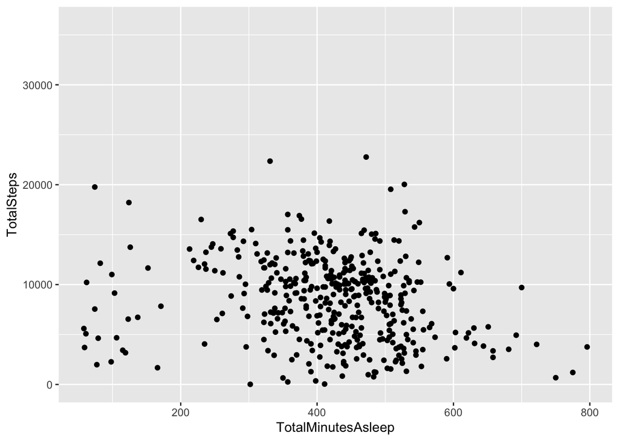

```r
ggplot(data=combined_noZeros, aes(x=TotalMinutesAsleep, y=TotalSteps)) + geom_point()
```

There appears to be no relationship between the two.

Let’s see if there’s a relationship/pattern in sedentary minutes and calories.

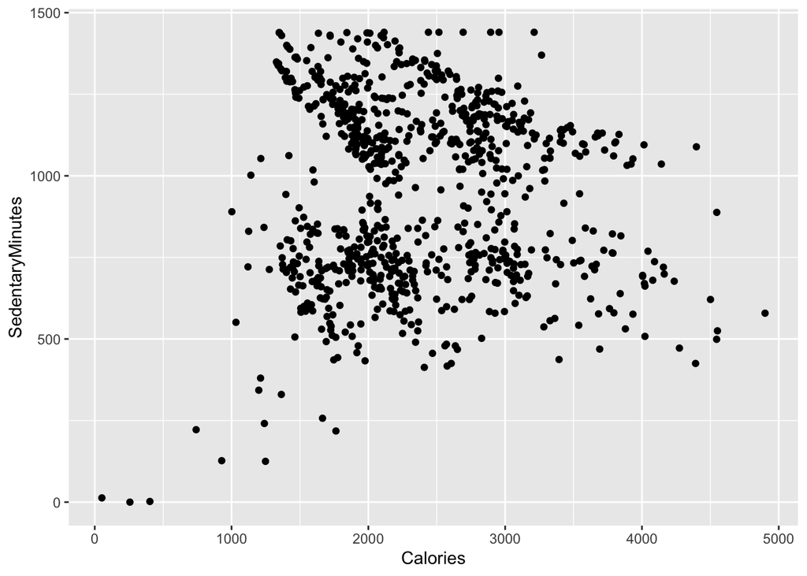

```r
ggplot(data=combined_noZeros, aes(x=Calories, y=SedentaryMinutes)) + geom_point()
```

There appears to be is somewhat of a negative relationship but is very weak. We cannot perform a correlation plot (without transforming the data) because we know that SedendaryMinutes was not normal. We can look at the normality and distribution of Calories for extra practice.

```r
shapiro.test(combined_noZeros$Calories)
```

```
##
##  Shapiro-Wilk normality test
##
## data:  combined_noZeros$Calories
## W = 0.97226, p-value = 9.455e-12
```

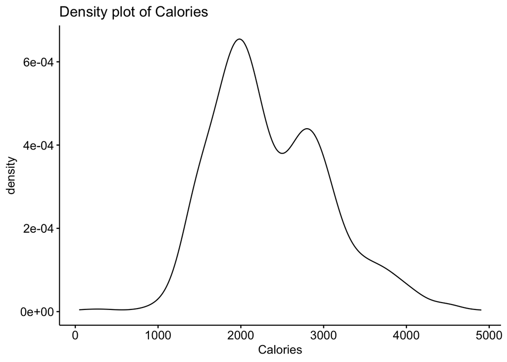

```r
ggdensity(combined_noZeros$Calories,
          main = "Density plot of Calories",
          xlab = "Calories")
```

Let’s move on and see if there’s a relationship/pattern in weight and sedentary minutes

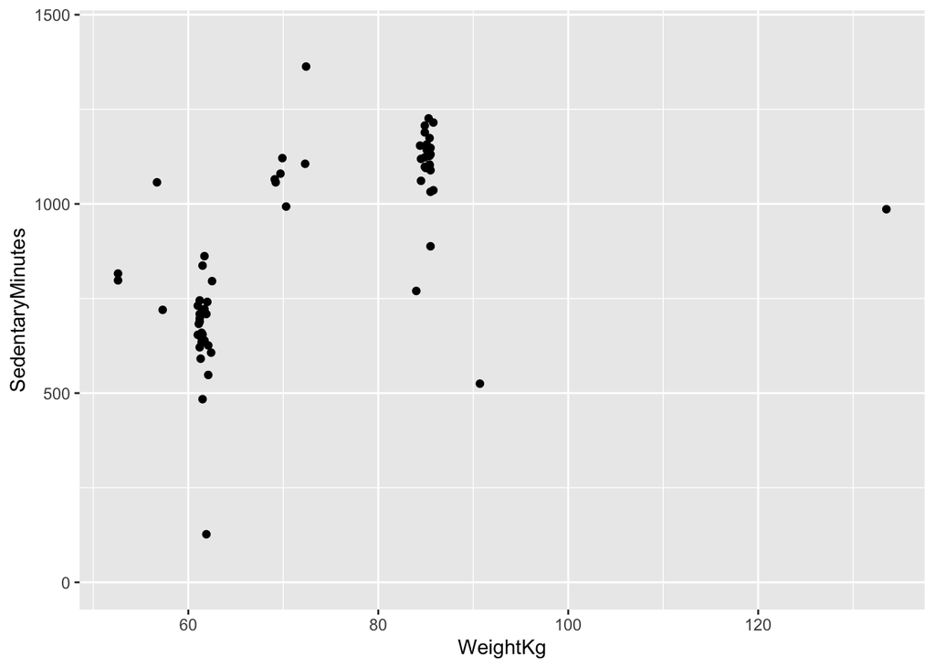

```r
ggplot(data=combined_noZeros, aes(x=WeightKg, y=SedentaryMinutes)) + geom_point()
```

Interestingly, there appears to be three clusters of weight ranges (one larger one around 60kg, one small one around 70kg, and one larger one around 85kg).

Also, it appears that individuals with lower weights tend to have fewer sedentary minutes, but do not know for certain because SedentaryMinutes does not have normal data and therefore we will not be performing a correlation analysis. We can check the normality and distribution of Weightkg for extra practice.

```r
shapiro.test(combined_noZeros$WeightKg)
```

```
##
##  Shapiro-Wilk normality test
##
## data:  combined_noZeros$WeightKg
## W = 0.77833, p-value = 1.124e-08
```

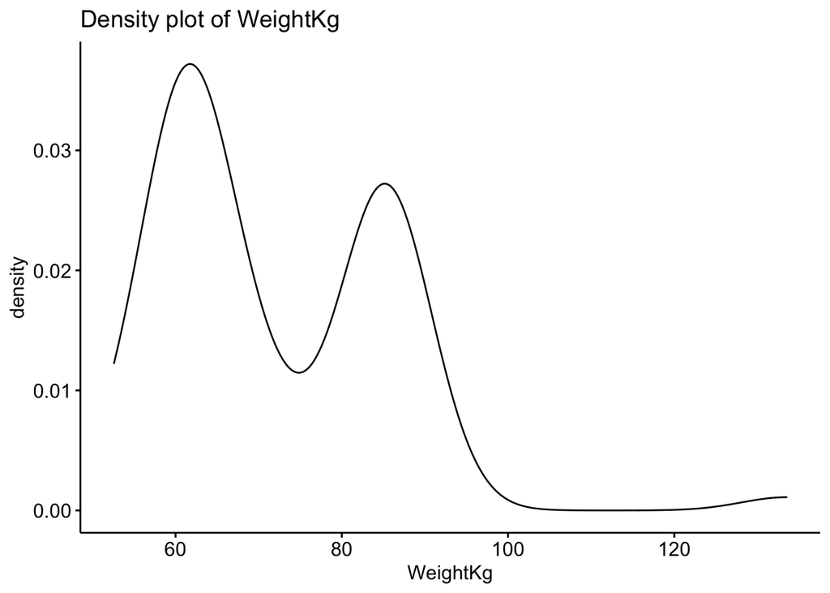

```r
ggdensity(combined_noZeros$WeightKg,
          main = "Density plot of WeightKg",
          xlab = "WeightKg")
```

```r
daily_minutes <- read.csv("Daily/dailyActivity_minutes.csv")
daily_distance <- read.csv("Daily/dailyActivity_distance.csv")
```

Load programs and plot.

```r
library(ggridges)
```

Reorder the levels.

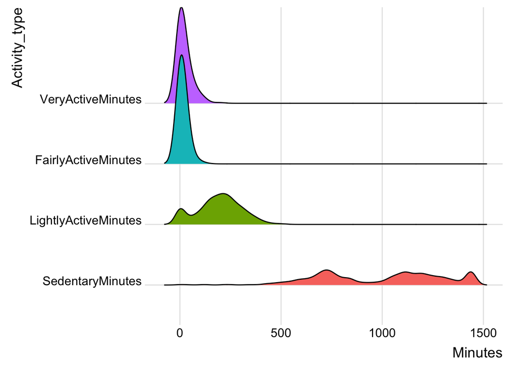

```r
daily_minutes <- daily_minutes %>%
  mutate(Activity_type = fct_relevel(Activity_type, levels = "SedentaryMinutes", "LightlyActiveMinutes", "FairlyActiveMinutes", "VeryActiveMinutes"))

ggplot(daily_minutes, aes(x = Minutes, y = Activity_type, fill = Activity_type)) +
  geom_density_ridges() +
  theme_ridges() +
  theme(legend.position = "none")
```

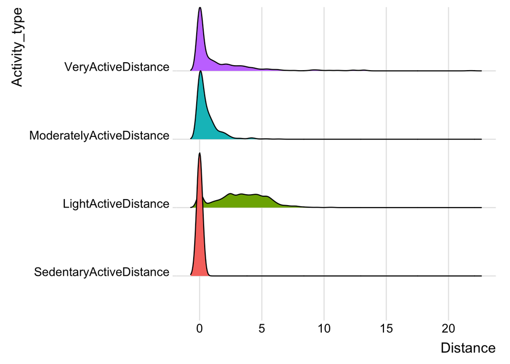

```r
daily_distance <- daily_distance %>%
  mutate(Activity_type = fct_relevel(Activity_type, levels = "SedentaryActiveDistance", "LightActiveDistance", "ModeratelyActiveDistance", "VeryActiveDistance"))

ggplot(daily_distance, aes(x = Distance, y = Activity_type, fill = Activity_type)) +
  geom_density_ridges() +
  theme_ridges() +
  theme(legend.position = "none")
```

Now let’s look at the relationship between total steps and calories.

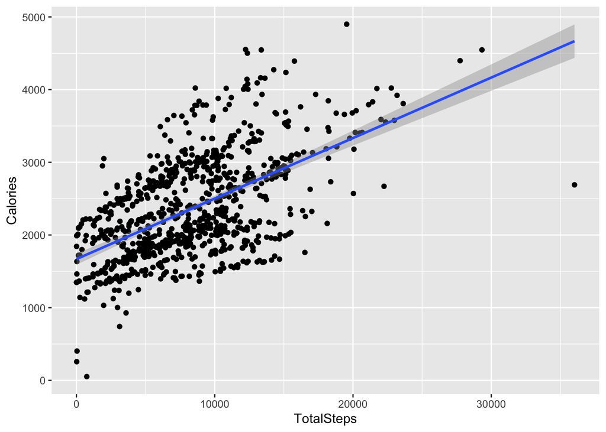

```r
ggplot(data=combined_noZeros, aes(x=TotalSteps, y = Calories))+ geom_point() + stat_smooth(method=lm)
```

It looks like there’s positive relationship between total steps and calories. Since we used a regression line, we assume that the residuals must be normally distributed and the variance of the residuals should be the same for the explanatory variables. Let’s check double check for those assumption.

```r
calories_lm <- lm(Calories ~ TotalSteps, data = combined_noZeros)
calories_res <- resid(calories_lm)
```

First let’s look at the variance of the residuals.

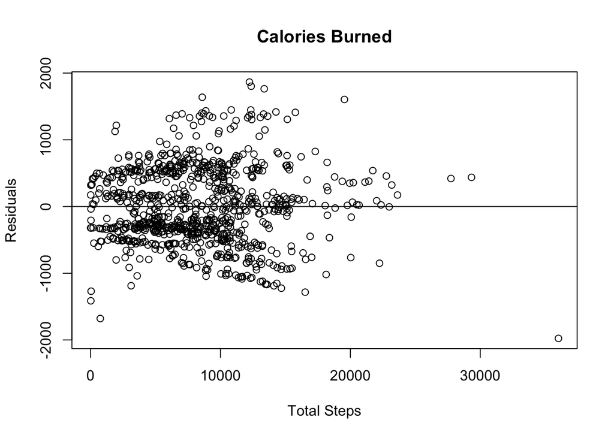

```r
plot(combined_noZeros$TotalSteps, calories_res, ylab="Residuals",
     xlab = "Total Steps", main = "Calories Burned")
abline(0,0)
```

They seem to be similar in variation.

Now let’s look at normality.

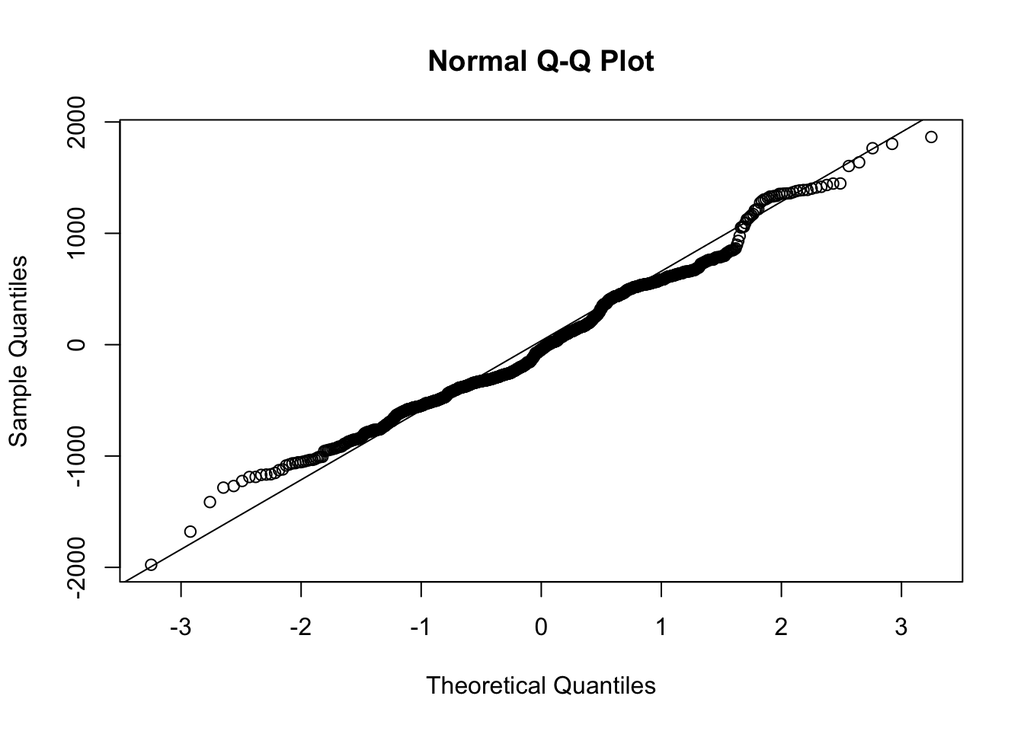

```r
qqnorm(calories_res)
qqline(calories_res)
```

It looks like the residuals are normally distributed.

Now we can get a summary of the linear model

```r
summary(calories_lm)
```

```
##
## Call:
## lm(formula = Calories ~ TotalSteps, data = combined_noZeros)
##
## Residuals:
##      Min       1Q   Median       3Q      Max
## -1976.66  -385.52   -43.53   457.04  1865.15
##
## Coefficients:
##              Estimate Std. Error t value Pr(>|t|)
## (Intercept) 1.669e+03  3.998e+01   41.75   <2e-16 ***
## TotalSteps  8.323e-02  4.175e-03   19.94   <2e-16 ***
## ---
## Signif. codes:  0 '***' 0.001 '**' 0.01 '*' 0.05 '.' 0.1 ' ' 1
##
## Residual standard error: 581.6 on 861 degrees of freedom
## Multiple R-squared:  0.3158, Adjusted R-squared:  0.315
## F-statistic: 397.4 on 1 and 861 DF,  p-value: < 2.2e-16
```

## Step 5: Export the data

Create a csv file that we can use in the future if want to perform further analyses.

We can filter out some of the columns to only include data would be using.

```r
filtered_combined_noZeros <- combined_noZeros %>%
  select('Id', 'TotalSteps', 'TotalDistance', 'VeryActiveDistance',
  'ModeratelyActiveDistance',   'LightActiveDistance',  'SedentaryActiveDistance',
  'VeryActiveMinutes',  'FairlyActiveMinutes',  'LightlyActiveMinutes',
  'SedentaryMinutes',   'Calories','TotalMinutesAsleep',    'TotalTimeInBed', 'WeightPounds')
```

```r
write.csv(filtered_combined_noZeros, file = 'daily_activies_noZeros.csv')
```

## Some conclusions:

More people log in their calories, steps taken, and intensities more than they log their sleep data. Very few individuals log in their weight.

Most of this data is not normally distributed, therefore we were unable to perform true correlation analysis in many of the variables. However, we can calculate an estimate of the calories burned by observing the number of steps taken.